# Data Anaylsis: Initial Assessment Questions

## Introduction

This markdown imports the Qualtrics data from the initial assessment and generates figures for publication.

There are two questions in the initial assessment: 1. Where in Africa were cases of Ebola Virus Disease most prevalent during the recent outbreak? 2. How many people are known to have contracted Ebola Virus Disease while in the United States?

## The first question was a heat map, so we can only use the standard Qualtrics output. But, we can make a customized chart for Q2.

## Required Packages

The following R packages are required for this script:

- here: for path setting
- tidyverse: for using all packages in the Tidyverse for data wrangling (ggplot2, dplyr, tidyr, readr, purr, tibble, stringr, and forcats)

## Load Data

```r
#define path to data
data_location <- here::here("data", "processed_data", "InitialAssessmentData_ALL.csv")

#load data
initial_data <- read.csv(data_location)
```

## Data Overview

Look at the data to ensure variables imported correctly.

```r
#data overview
summary(initial_data)
```

```
##      Map_X           Map_Y        EVD_Guess
##  Min.   : 54.0   Min.   : 34.0   Length:742
##  1st Qu.:138.5   1st Qu.:186.0   Class :character
##  Median :238.0   Median :235.0   Mode  :character
##  Mean   :244.7   Mean   :249.2
##  3rd Qu.:345.5   3rd Qu.:305.5
##  Max.   :540.0   Max.   :553.0
##  NA's   :3       NA's   :3
```

The `EVD_Guess` imported as a character variable, so we need to fix it to be a numeric variable.

## Data Transformation

Using `table(initial_data$EVD_guess)`, we can see the following values need to be adjusted:

- 50,000: remove the comma
- None: change to 0
- blank: change to `NA`

```r
#fix 50,000
initial_data$EVD_Guess[initial_data$EVD_Guess == "50,000"] <- 50000

#fix none
initial_data$EVD_Guess[initial_data$EVD_Guess == "None"] <- 0

#fix blanks
initial_data$EVD_Guess[initial_data$EVD_Guess == ""] <- NA

#convert to numeric
initial_data$EVD_Guess <- as.numeric(initial_data$EVD_Guess)
```

## Summary Stats

Generate summary statistics for EVD guess.

```r
#summary
summary(initial_data$EVD_Guess)
```

```
##    Min. 1st Qu.  Median    Mean 3rd Qu.    Max.    NA's
##     0.0     0.0     2.0   111.8     5.0 50000.0       4
```

```r
#mean
mean(initial_data$EVD_Guess, na.rm = TRUE)
```

```
## [1] 111.8293
```

```r
#sd
sd(initial_data$EVD_Guess, na.rm = TRUE)
```

```
## [1] 1862.357
```

## Outlier Adjustment

Remove the `50000` datapoint as it is an extreme outlier.

```r
#remove outlier (this also removes NAs)
data_adj <- subset(initial_data, EVD_Guess < 50000)

#summary
summary(data_adj$EVD_Guess)
```

```
##    Min. 1st Qu.  Median    Mean 3rd Qu.    Max.
##    0.00    0.00    2.00   44.14    5.00 5000.00
```

```r
#mean
mean(data_adj$EVD_Guess)
```

```
## [1] 44.1384
```

```r
#sd
sd(data_adj$EVD_Guess)
```

```
## [1] 294.8511
```

## Figure

Create figure for EVD guesses.

Also need to convert to categories to make it more comprehensible:

0 people 1 person 2 people 3 people 4 people 5 people 6 - 10 people 11 - 50 people 51 - 100 people More than 100 people

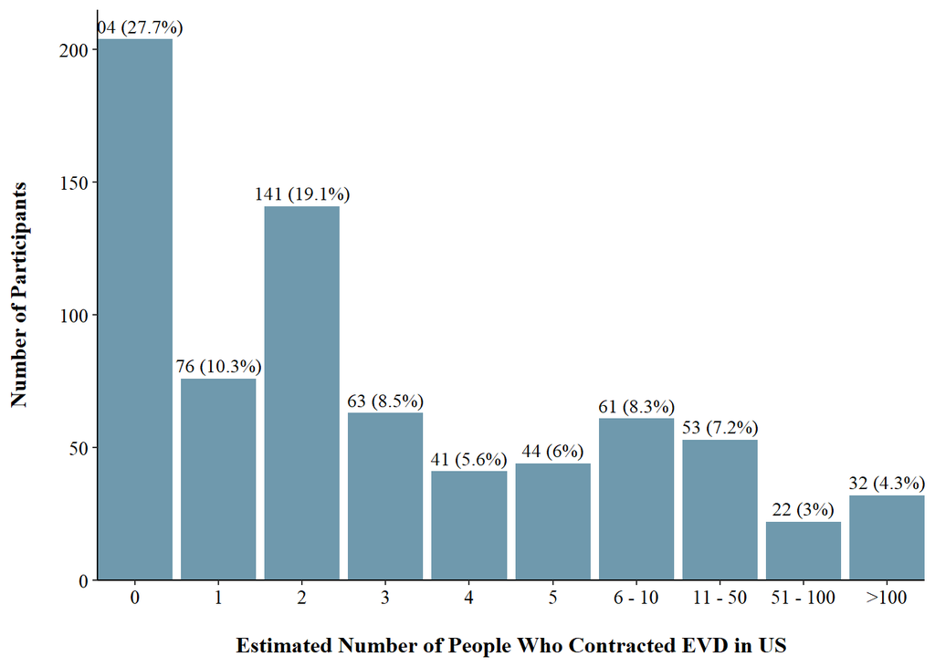

```r
#convert to categorical
data_adj$guess_cat <- cut(data_adj$EVD_Guess,
                          breaks = c(-1, 0.9, 1.9, 2.9, 3.9, 4.9, 5, 10, 50, 100, 5000),
                          labels = c("0", "1", "2", "3", "4", "5", "6 - 10", "11 - 50", "51 - 100", ">100"))

#create plot that includes both count and percentage of guesses
guess_plot <- data_adj %>%
                  dplyr::count(guess_cat) %>%
                  dplyr::mutate(perc = round(proportions(n) * 100, 1),
                                res = stringr::str_c(n, " (", perc, "%)"),
                                guess_cat = as.factor(guess_cat)) %>%
                  ggplot2::ggplot(mapping = aes(x = guess_cat, y = n)) +
                           geom_col(fill = "#6F99AD") +
                           geom_text(aes(label = res),
                                     vjust = -0.5,
                                     family = "serif",
                                     size = 3.5) +
                           scale_x_discrete(expand = c(0,0)) +
                           scale_y_continuous(expand = c(0,0),
                                              limits = c(0, 215)) +
                           labs(x = "\nEstimated Number of People Who Contracted EVD in US",
                                y = "Number of Participants\n") +
                           theme_classic() +
                           theme(text = element_text(family = "serif"),
                                 axis.text = element_text(color = "black", size = 11),
                                 axis.title = element_text(face = "bold", size = 12),
                                 legend.position = "none")

guess_plot
```

```r
#save file
guess_plot_file <- here::here("results", "Figure_2.png")

ggplot2::ggsave(guess_plot_file, width = 9, height = 5.5, dpi = 300, units = "in", device = "png")
```